# MPDW PRAKTIKUM 2 Bagian Sales dan Advert

Daffa Lukman Wahid Al Jailani

2026-05-25

# SOAL 1

## PREPARASI DATA

```r
library(readxl)
salesdata <- read_excel("C:\\Users\\Lenovo\\Downloads\\Data MPDW Prak.xlsx", sheet = "Sheet1")
colnames(salesdata) <- c("Y", paste0("X", 1))
data.frame(salesdata)
```

```
##       Y   X1
## 1  3.63 0.97
## 2  4.20 0.95
## 3  3.33 0.99
## 4  4.54 0.91
## 5  2.89 0.98
## 6  4.87 0.90
## 7  4.90 0.89
## 8  5.29 0.86
## 9  6.18 0.85
## 10 7.20 0.82
## 11 7.25 0.79
## 12 6.09 0.83
## 13 6.80 0.81
## 14 8.65 0.77
## 15 8.43 0.76
## 16 8.29 0.80
## 17 7.18 0.83
## 18 7.90 0.79
## 19 8.45 0.76
## 20 8.23 0.78
```

## EKSPLORASI

```r
library(dplyr)
```

```r
library(ggplot2)
library(psych)
library(GGally)
library(corrplot)
library(TTR)
library(forecast)
library(lmtest)
library(orcutt) #untuk membuat model regresi Cochrane-Orcutt
library(HoRM) #untuk membuat model regresi Hildreth-Lu
# Struktur data
str(salesdata)
```

```
## tibble [20 × 2] (S3: tbl_df/tbl/data.frame)
##  $ Y : num [1:20] 3.63 4.2 3.33 4.54 2.89 4.87 4.9 5.29 6.18 7.2 ...
##  $ X1: num [1:20] 0.97 0.95 0.99 0.91 0.98 0.9 0.89 0.86 0.85 0.82 ...
```

```r
# Statistik Deskriptif
describe(salesdata)
```

```
##    vars  n mean   sd median trimmed  mad  min  max range  skew kurtosis   se
## Y     1 20 6.22 1.89   6.49    6.31 2.49 2.89 8.65  5.76 -0.26    -1.43 0.42
## X1    2 20 0.85 0.08   0.83    0.85 0.08 0.76 0.99  0.23  0.51    -1.19 0.02
```

## OLS

```r
model <- lm(
  Y ~ X1,
  data = salesdata
)

summary(model)
```

```
##
## Call:
## lm(formula = Y ~ X1, data = salesdata)
##
## Residuals:
##      Min       1Q   Median       3Q      Max
## -0.73068 -0.29764 -0.00966  0.30224  0.81193
##
## Coefficients:
##             Estimate Std. Error t value Pr(>|t|)
## (Intercept)   26.910      1.110   24.25 3.39e-15 ***
## X1           -24.290      1.298  -18.72 3.02e-13 ***
## ---
## Signif. codes:  0 '***' 0.001 '**' 0.01 '*' 0.05 '.' 0.1 ' ' 1
##
## Residual standard error: 0.4287 on 18 degrees of freedom
## Multiple R-squared:  0.9511, Adjusted R-squared:  0.9484
## F-statistic: 350.3 on 1 and 18 DF,  p-value: 3.019e-13
```

Didapat model OLS:
$$Y = 26.91 - 24.290X_1$$
## DIAGNOSTIK

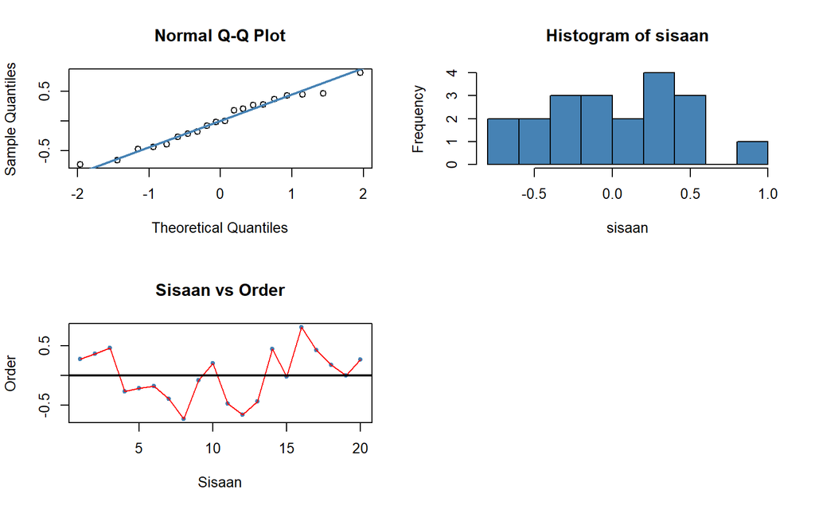

```r
#sisaan dan fitted value
sisaan<- residuals(model)
fitValue<- predict(model)

#Diagnostik dengan eksploratif
par(mfrow = c(2,2))
qqnorm(sisaan)
qqline(sisaan,
       col = "steelblue",
       lwd = 2)

hist(sisaan,
     col = "steelblue")
plot(seq_along(sisaan), sisaan,
     col = "steelblue",
     pch = 20,
     xlab = "Sisaan",
     ylab = "Order",
     main = "Sisaan vs Order")
lines(seq_along(sisaan),
      sisaan,
      col = "red")
abline(a = 0, b = 0, lwd = 2)
```

## NORMALITAS SISAAN

```r
#Melihat Sisaan Menyebar Normal/Tidak
#H0: sisaan mengikuti sebaran normal
#H1: sisaan tidak mengikuti sebaran normal
shapiro.test(sisaan)
```

```
##
##  Shapiro-Wilk normality test
##
## data:  sisaan
## W = 0.9744, p-value = 0.8437
```

```r
ks.test(sisaan, "pnorm", mean=mean(sisaan), sd=sd(sisaan))
```

```
##
##  Exact one-sample Kolmogorov-Smirnov test
##
## data:  sisaan
## D = 0.11606, p-value = 0.9222
## alternative hypothesis: two-sided
```

BErdasarkan uji Formal, nilai p-value > 0.05 artinya sisaan menyebar normal.

## AUTOKORELASI

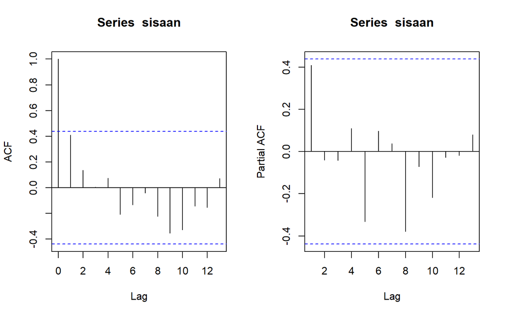

```r
par(mfrow = c(1,2))
acf(sisaan)
pacf(sisaan)
```

Berdasarkan plot ACF dan PACF, tidak terdapat indikasi Autokorelasi. Namun, untuk lebih memastikan akan dilakukan uji formal dengan uji Durbin Watson.

```r
#Deteksi autokorelasi dengan uji-Durbin Watson
#H0: tidak ada autokorelasi
#H1: ada autokorelasi
dwtest(model)
```

```
##
##  Durbin-Watson test
##
## data:  model
## DW = 1.1358, p-value = 0.009813
## alternative hypothesis: true autocorrelation is greater than 0
```

Berdasarkan hasil DW Test, didapatkan nilai $DW = 1.1358$ dan *p-value* = $0.009813$. Berdasarkan tabel Durbin-Watson diperoleh nilai $DL = 1.2015$ dan $DU = 1.4107$. Nilai DW masih berada di bawah nilai DL. Artinya, berada di daerah penolakan H0. didukung dengan nilai *p-value* < 0.05 dapat disimpulkan bahwa tolak H0, cukup bukti mengatakan adanya autokorelasi. Oleh karena itu, diperlukan penangan autokorelasi. Penanganan yang akan digunakan menggunakan dua metode, yaitu Cochrane-Orcutt dan Hildret-Lu.

## PENANGANAN AUTOKORELASI

### Cochrane-Orcutt

```r
#Penanganan Autokorelasi Cochrane-Orcutt
modelCO<-cochrane.orcutt(model)
modelCO
```

```
## Cochrane-orcutt estimation for first order autocorrelation
##
## Call:
## lm(formula = Y ~ X1, data = salesdata)
##
##  number of interaction: 8
##  rho 0.425232
##
## Durbin-Watson statistic
## (original):    1.13582 , p-value: 9.813e-03
## (transformed): 1.95804 , p-value: 4.151e-01
##
##  coefficients:
## (Intercept)          X1
##    26.72209   -24.08413
```

```r
rho <- modelCO$rho
```

```r
salesdata$Y
```

```
##  [1] 3.63 4.20 3.33 4.54 2.89 4.87 4.90 5.29 6.18 7.20 7.25 6.09 6.80 8.65 8.43
## [16] 8.29 7.18 7.90 8.45 8.23
```

```r
salesdata$X1
```

```
##  [1] 0.97 0.95 0.99 0.91 0.98 0.90 0.89 0.86 0.85 0.82 0.79 0.83 0.81 0.77 0.76
## [16] 0.80 0.83 0.79 0.76 0.78
```

```r
salesdata$Y[-1]
```

```
##  [1] 4.20 3.33 4.54 2.89 4.87 4.90 5.29 6.18 7.20 7.25 6.09 6.80 8.65 8.43 8.29
## [16] 7.18 7.90 8.45 8.23
```

```r
salesdata$X1[-1]
```

```
##  [1] 0.95 0.99 0.91 0.98 0.90 0.89 0.86 0.85 0.82 0.79 0.83 0.81 0.77 0.76 0.80
## [16] 0.83 0.79 0.76 0.78
```

```r
#Transformasi Manual
Y.trans<- salesdata$Y[-1]-salesdata$Y[-20]*rho
X.trans<- salesdata$X1[-1]-salesdata$X1[-20]*rho
modelCOmanual<- lm(Y.trans~X.trans)
summary(modelCOmanual)
```

```
##
## Call:
## lm(formula = Y.trans ~ X.trans)
##
## Residuals:
##      Min       1Q   Median       3Q      Max
## -0.55508 -0.25069 -0.05506  0.25007  0.83017
##
## Coefficients:
##             Estimate Std. Error t value Pr(>|t|)
## (Intercept)  15.3590     0.9385   16.36 7.71e-12 ***
## X.trans     -24.0841     1.9385  -12.42 5.90e-10 ***
## ---
## Signif. codes:  0 '***' 0.001 '**' 0.01 '*' 0.05 '.' 0.1 ' ' 1
##
## Residual standard error: 0.3955 on 17 degrees of freedom
## Multiple R-squared:  0.9008, Adjusted R-squared:  0.895
## F-statistic: 154.4 on 1 and 17 DF,  p-value: 5.903e-10
```

```r
#Mencari Penduga Koefisien Regresi setelah Transformasi ke Persamaan Awal
b0bintang <- modelCOmanual$coefficients[-2]
b0 <- b0bintang/(1-rho)
b1 <- modelCOmanual$coefficients[-1]
b0
```

```
## (Intercept)
##    26.72209
```

```r
b1
```

```
##   X.trans
## -24.08413
```

Hasil ini akan sama jika kita menggunakan metode Huldret-Lu,

### Hildret-Lu

```r
# ambil y dan x (satu prediktor saja)
y <- salesdata$Y
x <- salesdata$X1

# grid search rho 0–0.9
r <- seq(0, 0.9, by = 0.1)
tab <- data.frame(
  rho = r,
  SSE = sapply(r, function(rr) deviance(hildreth.lu(y, x, rr)))
)

tab            # tabel rho vs SSE
```

```
##    rho      SSE
## 1  0.0 3.212112
## 2  0.1 2.979074
## 3  0.2 2.810498
## 4  0.3 2.705239
## 5  0.4 2.661188
## 6  0.5 2.674924
## 7  0.6 2.741983
## 8  0.7 2.858804
## 9  0.8 3.026489
## 10 0.9 3.252863
```

```r
rho_hat <- tab$rho[which.min(tab$SSE)]   # rho terbaik
fit_hl  <- hildreth.lu(y, x, rho_hat)    # model final
summary(fit_hl)
```

```
##
## Call:
## lm(formula = y ~ x)
##
## Residuals:
##      Min       1Q   Median       3Q      Max
## -0.56476 -0.24781 -0.05422  0.25392  0.82998
##
## Coefficients:
##             Estimate Std. Error t value Pr(>|t|)
## (Intercept)   16.070      0.957   16.79 5.10e-12 ***
## x            -24.158      1.892  -12.77 3.88e-10 ***
## ---
## Signif. codes:  0 '***' 0.001 '**' 0.01 '*' 0.05 '.' 0.1 ' ' 1
##
## Residual standard error: 0.3957 on 17 degrees of freedom
## Multiple R-squared:  0.9055, Adjusted R-squared:    0.9
## F-statistic:   163 on 1 and 17 DF,  p-value: 3.88e-10
```

```r
#Penanganan Autokorelasi Hildreth lu
# Hildreth-Lu
hildreth.lu.func<- function(r, model){
  x <- model.matrix(model)[,-1]
  y <- model.response(model.frame(model))
  n <- length(y)
  t <- 2:n
  y <- y[t]-r*y[t-1]
  x <- x[t]-r*x[t-1]

  return(lm(y~x))
}

#Pencariab rho yang meminimumkan SSE
r <- c(seq(0.1,0.9, by= 0.1))
tab <- data.frame("rho" = r, "SSE" = sapply(r, function(i){deviance(hildreth.lu.func(i, model))}))
round(tab, 4)
```

```
##   rho    SSE
## 1 0.1 2.9791
## 2 0.2 2.8105
## 3 0.3 2.7052
## 4 0.4 2.6612
## 5 0.5 2.6749
## 6 0.6 2.7420
## 7 0.7 2.8588
## 8 0.8 3.0265
## 9 0.9 3.2529
```

Pertama-tama akan dicari di mana kira-kira $ρ$ yang menghasilkan SSE minimum. Pada hasil di atas terlihat $ρ$ minimum ketika 0.4. Namun, hasil tersebut masih kurang teliti sehingga akan dicari kembali $ρ$ yang lebih optimum dengan ketelitian yang lebih. Jika sebelumnya jarak antar $ρ$ yang dicari adalah 0.1, kali ini jarak antar $ρ$ adalah 0.001 dan dilakukan pada selang 0.3 sampai dengan 0.5.

```r
#Rho optimal di sekitar 0.4
rOpt <- seq(0.3,0.5, by= 0.001)
tabOpt <- data.frame("rho" = rOpt, "SSE" = sapply(rOpt, function(i){deviance(hildreth.lu.func(i, model))}))
head(tabOpt[order(tabOpt$SSE),])
```

```
##       rho      SSE
## 126 0.425 2.659368
## 127 0.426 2.659370
## 125 0.424 2.659372
## 128 0.427 2.659377
## 124 0.423 2.659382
## 129 0.428 2.659390
```

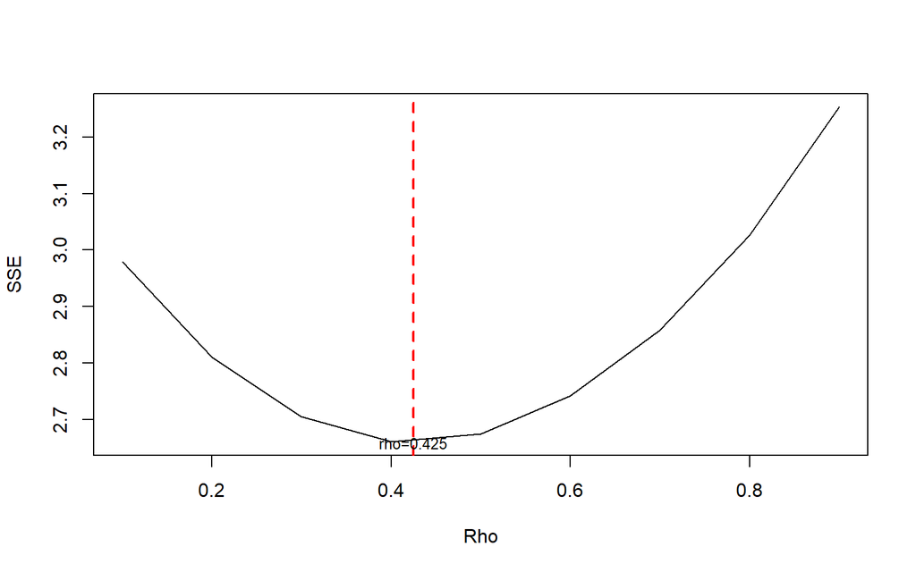

```r
#Grafik SSE optimum
par(mfrow = c(1,1))
plot(tab$SSE ~ tab$rho , type = "l", xlab = "Rho", ylab = "SSE")
abline(v = tabOpt[tabOpt$SSE==min(tabOpt$SSE),"rho"], lty = 2, col="red",lwd=2)
text(x=0.425, y=2.659368, labels = "rho=0.425", cex = 0.8)
```

Perhitungan yang dilakukan aplikasi `R` menunjukkan bahwa nilai $ρ$ optimum, yaitu saat SSE terkecil terdapat pada nilai $ρ=0.425$. Hal tersebut juga ditunjukkan pada plot. Selanjutnya, model dapat didapatkan dengan mengevaluasi nilai $ρ$ ke dalam fungsi `hildreth.lu.func`, serta dilanjutkan dengan pengujian autokorelasi dengan uji Durbin-Watson. Namun, setelah pengecekan tersebut tidak lupa koefisien regresi tersebut digunakan untuk transformasi balik. Persamaan hasil transformasi itulah yang menjadi persamaan sesungguhnya.

```r
#Model terbaik
modelHL <- hildreth.lu.func(0.425, model)
summary(modelHL)
```

```
##
## Call:
## lm(formula = y ~ x)
##
## Residuals:
##      Min       1Q   Median       3Q      Max
## -0.55517 -0.25066 -0.05505  0.25010  0.83017
##
## Coefficients:
##             Estimate Std. Error t value Pr(>|t|)
## (Intercept)  15.3655     0.9387   16.37 7.68e-12 ***
## x           -24.0848     1.9380  -12.43 5.88e-10 ***
## ---
## Signif. codes:  0 '***' 0.001 '**' 0.01 '*' 0.05 '.' 0.1 ' ' 1
##
## Residual standard error: 0.3955 on 17 degrees of freedom
## Multiple R-squared:  0.9008, Adjusted R-squared:  0.895
## F-statistic: 154.4 on 1 and 17 DF,  p-value: 5.88e-10
```

```r
#Transformasi Balik
cat("y = ", coef(modelHL)[1]/(1-0.425), "", coef(modelHL)[2],"x", sep = "")
```

```
## y = 26.72268-24.08484x
```

Setelah dilakukan tranformasi balik, didapatkan model dengan metode Hildreth-Lu sebagai berikut.
$$y =
26.72268-24.08484x$$

## PEMERIKSAAN ULANG AUTOKORELASI

```r
#Deteksi autokorelasi
dwtest(modelHL)
```

```
##
##  Durbin-Watson test
##
## data:  modelHL
## DW = 1.9577, p-value = 0.4148
## alternative hypothesis: true autocorrelation is greater than 0
```

Hasil tes Durbin-Watson menunjukkan bahwa nilai DW dan p-value menjadi $1.9577$ dan $0.4148$. Nilai DW sudah berada pada rentang DU < DW < 4-DU atau $1.4107 < DW < 2.5893$. Hal tersebut juga didukung dengan nilai *p-value* > 0.05, artinya belum cukup bukti menyatakan bahwa sisaan terdapat autokorelasi pada taraf nyata 5%.

## PERBANDINGAN METODE

```r
#Perbandingan
sseModelawal <- anova(model)$`Sum Sq`[-1]
sseModelCO <- anova(modelCOmanual)$`Sum Sq`[-1]
sseModelHL <- anova(modelHL)$`Sum Sq`[-1]
mseModelawal <- sseModelawal/nrow(salesdata)
mseModelCO <- sseModelCO/nrow(salesdata)
mseModelHL <- sseModelHL/nrow(salesdata)
akurasi <- matrix(c(sseModelawal,sseModelCO,sseModelHL,
                    mseModelawal,mseModelCO,mseModelHL),nrow=2,ncol=3,byrow = T)
colnames(akurasi) <- c("Model Awal", "Model Cochrane-Orcutt", "Model Hildreth-Lu")
row.names(akurasi) <- c("SSE","MSE")
akurasi
```

```
##     Model Awal Model Cochrane-Orcutt Model Hildreth-Lu
## SSE  3.3082574             2.6593681         2.6593683
## MSE  0.1654129             0.1329684         0.1329684
```

Dari hasil perbandingan nilai SSE dan MSE dari model Cochrane-Orcutt dan model Hildreth-Lu sama, dan lebih baik dari model awal.